1.Brainstorm at least 5 different ways to assess the typical delay characteristics of a group of flights. Consider the following scenarios: A flight is 15 minutes early 50% of the time, and 15 minutes late 50% of the time. A flight is always 10 minutes late. A flight is 30 minutes early 50% of the time, and 30 minutes late 50% of the time. 99% of the time a flight is on time. 1% of the time it’s 2 hours late. Which is more important: arrival delay or departure delay?

I could not figure out what “Brainstorm at least 5 different ways to assess the typical delay characteristics of a group of flights” means. But Arrival delay is more important because it might influence on passenger’s schedule. And additional cost for the compensation occur.

2.Come up with another approach that will give you the same output as not_cancelled %>% count(dest) and not_cancelled %>% count(tailnum, wt = distance) (without using count()).

not_cancelled %>% group_by(dest) %>% summarise(n = n())

not_cancelled %>% group_by(tailnum) %>% summarise(n = sum(distance))

3. Our definition of cancelled flights (is.na(dep_delay) | is.na(arr_delay) ) is slightly suboptimal. Why? Which is the most important column?

Some flights departed but did not arrived at airport for some reasons. They might crashed on the way to the airport or had problem therefore they changed their destination. Thus most important column is arr_delay because numbers of valid elements in this columns represent the number of flights that is operated.

4. Look at the number of cancelled flights per day. Is there a pattern? Is the proportion of cancelled flights related to the average delay? ggplot(CancelledPerDay) + geom_point(aes(x = FlightsCounts, y = CancelledCounts))

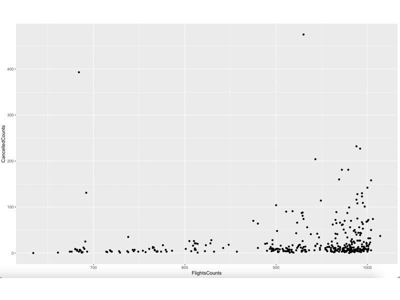

[figure not shown]

This graph has Average of arr_delay as X-axis and proportion of cancelled flights as Y-axis. Seems they have strong positive correlation.

5. Which carrier has the worst delays? Challenge: can you disentangle the effects of bad airports vs. bad carriers? Why/why not? (Hint: think about flights %>% group_by(carrier, dest) %>% summarise(n()))

flights %>% + group_by(carrier) %>% + summarise(arr_delay = mean(arr_delay)) %>% + arrange(desc(arr_delay)) # A tibble: 16 x 2 carrier arr_delay 1 F9 21.9  
2 FL 20.1  
3 EV 15.8  
4 YV 15.6  
5 OO 11.9  
6 MQ 10.8

F9 is the worst carrier

flights %>% + group_by(dest) %>% + summarise(arr_delay = mean(arr_delay, na.rm = TRUE)) %>% + arrange(desc(arr_delay)) # A tibble: 105 x 2 dest arr_delay 1 CAE 41.8 2 TUL 33.7 3 OKC 30.6 4 JAC 28.1 5 TYS 24.1

As this table shows, Destination might affect the lateness. Worst airport is CAE and flights to CAE are 41.8 minutes late on average. That’s huge. But I could not disentangle the effects of bad airports vs. bad carriers.

6. What does the sort argument to count() do. When might you use it? The results that is provided with count() are sorted into descending order. We might use it when we want to find maximum count of elements in a column.